# Combined effects of warming and hypoxia on early life stage Chinook salmon physiology and development | Conservation Physiology | Oxford Academic

[figure not shown]

[figure not shown]

[figure not shown]

Journal Article

# Combined effects of warming and hypoxia on early life stage Chinook salmon physiology and development

Author Notes

*Conservation Physiology*, Volume 7, Issue 1, 2019, coy078, https://doi-org.reed.idm.oclc.org/10.1093/conphys/coy078

Published:

18 February 2019

Article history

## Abstract

Early life stages of salmonids are particularly vulnerable to warming and hypoxia, which are common stressors in hyporheic, gravel bed, rearing habitat (i.e. a ‘redd’). With the progression of global climate change, high temperatures and hypoxia may co-occur more frequently within redds, particularly for salmonid species at their southern range limit. Warming and hypoxia have competing effects on energy supply and demand, which can be detrimental to energy-limited early life stages. We examined how elevated temperature and hypoxia as individual and combined stressors affected the survival, physiological performance, growth, and development of Chinook salmon (*Oncorhynchus tshawytscha*). We reared late fall-run Chinook salmon from fertilization to the fry stage in a fully factorial design of two temperatures [10°C (ambient) and 14°C (warm)] and two oxygen levels [normoxia (100% air saturation, 10 mg O<sub>2</sub>/l) and hypoxia (50% saturation, 5.5 mg O<sub>2</sub>/l)]. Rearing in hypoxia significantly reduced hatching success, especially in combination with warming. Both warming and hypoxia improved acute thermal tolerance. While rearing in hypoxia improved tolerance to acute hypoxia stress, warming reduced hypoxia tolerance. Hypoxia-reared fish were smaller at hatch, but were able to reach similar sizes to the normoxia-reared fish by the fry stage. High temperature and normoxia resulted in the fastest rate of development while low temperature and hypoxia resulted in the slowest rate of development. Despite improved physiological tolerance to acute heat and hypoxia stress, hypoxia-reared embryos had reduced survival and growth, which could have larger population-level effects. These results suggest that both warming and hypoxia are important factors to address in conservation strategies for Chinook salmon.

Issue Section:

[Research article](https://academic-oup-com.reed.idm.oclc.org/conphys/search-results?f_TocHeadingTitleList=Research+article)

## Introduction

Increasing water temperatures resulting from climate change are predicted to be problematic for numerous species, particularly for fishes such as Pacific salmonids, which require cool, flowing, highly oxygenated water (Moyle, 2002). The Central Valley watershed of California supports the southernmost populations of Chinook salmon (*Oncorhynchus tshawytscha)*, and is projected to see large, consistent temperature increases nearing 5°C this century (Hayhoe *et al.*, 2004; Dettinger, 2005). In addition to warming, hypoxia (low dissolved oxygen [DO] in the environment) is rapidly becoming more prevalent globally because of climate change and anthropogenic influences, such as eutrophication from agriculture and sewage runoff (Diaz, 2001; Breitburg *et al.*, 2018). Warming and hypoxia are likely to co-occur, as oxygen is less soluble in warmer water (Keeling *et al.*, 2010; Helm *et al.*, 2011). In California, the effects of climate change have been exacerbated by prolonged drought, as warming and low water flows increase water temperatures and thus the potential for hypoxia to occur (Hanak *et al.*, 2015). While the effects of each stressor on animal physiology have been studied in depth individually, there is a greater need to study the interaction between the two stressors in environmentally relevant scenarios (Crain *et al.*, 2008; Todgham and Stillman, 2013; Gunderson *et al.*, 2016).

Both warming and hypoxia are common stressors within the microhabitat of salmon redds, the gravel nests where embryos and larvae develop within the streambed. Temperature and DO within redds are influenced by numerous abiotic and biotic factors including intragravel flow velocity, sedimentation, gravel size, groundwater upwelling and oxygen consumption by developing embryos or other organic matter present (Acornley, 1999; Greig *et al.*, 2007a; Sear *et al.*, 2014). Hypoxia within redds has been correlated with detrimental effects on survival and growth of developing salmonids in natural streams (Rubin and Glimsäter, 1996; Youngson *et al.*, 2004; Greig *et al.*, 2007b). In California, as with many river systems, the rearing conditions for egg and fry development are determined by water releases from dams upstream. These water releases further dictate key abiotic water parameters downstream including temperature and DO. The combination of warming and low DO as a result of low water flows is thought to have reduced the thermal tolerance, and thus survival, of Chinook salmon embryos in the Sacramento River (Martin *et al.*, 2017).

From a physiological perspective, warming and hypoxia are likely to interact through contrasting effects on energy metabolism. Temperature is a controlling factor that determines metabolic rates in ectotherms, whereas oxygen is a limiting factor that restricts metabolic rate (Fry, 1971). Therefore, as warming increases metabolism, hypoxia limits the oxygen supply available to support increased metabolic demand (McBryan *et al.*, 2013). The concept of oxygen and capacity limitation of thermal tolerance (OCLTT) hypothesizes that the mismatch in oxygen supply and demand can reduce thermal tolerance and affect the physiology and ecology of many species (Pörtner, 2001). The OCLTT hypothesis predicts temperature and oxygen will interact negatively to influence stress tolerance such that exposure to high temperature is expected to reduce hypoxia tolerance and hypoxia is expected to reduce thermal tolerance (McBryan *et al.*, 2013).

Early life stages of Chinook salmon are particularly sensitive to both warming and hypoxia, as embryos and alevins are the least thermally tolerant life stages and have little to no mobility to avoid suboptimal habitat conditions (McCullough, 1999; Myrick and Cech, 2004). Embryos of oviparous fish such as salmonids have stronger energy constraints than older organisms because they possess a finite amount of energy in the form of yolk to support their development (Rombough, 2006). Under optimal conditions during development, the majority of energy is allocated towards growth. When energy supply or demand is altered, as with warming or hypoxia, there is increased competition for energy between coping with stress and continued growth and development (Sokolova, 2013). With a limited ability to increase aerobic metabolic rate above routine levels, compensatory energy partitioning may detract energy from processes necessary for development (Rombough, 2011). Therefore, the metabolic interactions between warming and hypoxia may be especially detrimental during early development.

Developing salmon are known to be sensitive to warming and hypoxia individually but are likely to experience both stressors simultaneously in their rearing environment, especially as climate change progresses and local anthropogenic impacts (e.g. drought) persist. In this study, we assessed the effects of chronic warming and hypoxia, on developing late fall-run Chinook salmon, as individual and combined stressors. We reared salmon from fertilization through the fry stage in a fully factorial design of two temperatures (10 and 14°C) and two oxygen levels (100% and 50% air saturation). Throughout development we measured hatching success, growth and developmental rate as well as tolerance to acute thermal and hypoxic stress to examine the lethal and sublethal responses to rearing in each treatment. We predicted that there would be detrimental effects of warming and hypoxia as individual stressors that would be amplified through synergistic interactions in the multiple stressor treatment due to competing effects on balancing energy supply and demand. Examining the effects of two key stressors across salmon development will further our understanding of the capacity of early life stage salmonids to cope with multiple stressors in their natural environment. Our findings can also inform water management strategies to promote egg to fry survival in highly managed, complex systems such as the Sacramento River.

## Materials and methods

### Fish acquisition and care

Freshly fertilized late fall-run Chinook salmon embryos were obtained from four separate breeding pairs spawned at the Coleman National Fish Hatchery (US Fish and Wildlife Service, Anderson, CA, USA). Embryos were transported to the University of California Davis Center for Aquatic Biology and Aquaculture in January 2017. Embryos were immediately transferred to their rearing treatments in one of four replicate 19 l square culture buckets. Embryos were held in floating mesh baskets affixed with plastic dividers creating individual wells to keep embryos separated in an even layer. Embryos from all four families were evenly distributed across each replicate bucket. Once alevins could sustain swimming, the baskets were removed from the culture buckets. Since early developmental stages rely on endogenous yolk reserves (Kamler, 2008), fish were not fed during the experiment. The experiment ended when fish reached the fry stage and nearly all of the yolk sac was absorbed. All fish care and protocols were reviewed and approved by the UC Davis Institutional Animal Care and Use Committee (protocol no. 19 593).

### Experimental design

To assess the effects of elevated temperature and decreased oxygen as individual and combined stressors, we reared developing Chinook salmon from fertilization to the fry stage in four treatments in a fully factorial design of two temperatures [10°C (ambient) and 14°C (warm)] and two oxygen (O<sub>2</sub>) saturation levels [normoxia (100% air saturation, 10 mg O<sub>2</sub>/l) and hypoxia (50% saturation, 5.5 mg O<sub>2</sub>/l)]. Ambient temperature of 10°C was chosen as this is within the average range of temperatures in the Sacramento River when late fall-run salmon embryos are present (Bureau of Reclamation (2018), Central Valley Operations, Sacramento River Temperature Report). The warm temperature of 14°C was chosen to represent a 4°C increase of water temperatures projected with climate change and is a potentially stressful, but not lethal, temperature because embryo mortality increases around 16°C in California Chinook salmon (Myrick and Cech, 2004; Williams, 2006). Dissolved oxygen within natural redds can fluctuate widely between 2–11 mg O<sub>2</sub>/l (Coble, 1961; Peterson and Quinn, 1996). Normoxia was maintained at 100% saturation to represent optimal habitat conditions and 50% was chosen as a moderate level of hypoxia that is potentially stressful, but not lethal (Silver *et al.*, 1963). Two different temperature treatments were maintained by placing culture and reservoir buckets in four large water bath tanks (1.2 m in diameter) containing flow through water at the corresponding treatment temperature. Each water bath (at 10°C or 14°C) held two culture buckets from the normoxia and hypoxia treatments, with two replicate water bath tanks for each temperature (*n* = 4 culture buckets per temperature and DO treatment combination). Oxygen saturation was manipulated using mass flow controller valves (Sierra Instruments, Monterey, CA, USA) to mix N<sub>2</sub> gas and air to maintain low DO in hypoxic treatments or air alone for normoxic treatments. The gas mixture was bubbled into reservoir buckets using venturi injectors (one reservoir bucket for each temperature × DO treatment). Equilibrated treatment water from each reservoir was then dripped into the culture buckets holding salmon at 16 l/h to ensure high turnover. Gas mixtures were also bubbled directly into culture buckets through air stones for further mixing and adjustment of DO levels within each individual bucket. Temperature and DO were measured in each culture bucket, reservoir bucket, and water bath tank daily using a handheld meter (OxyGuard Handy Polaris 2, OxyGuard International, Farum, Denmark), summarized in Table 1.

Table 1:

Water temperature (°C) and dissolved oxygen (DO, mg/l and % saturation) in each treatment for the duration of the experiment. Water temperature was measured daily in each water bath tank and is reported as the average between the duplicate tanks for each temperature treatment (±SD). Dissolved oxygen was measured daily in each culture bucket and is reported as the average of the four replicate culture buckets per treatment (±SD).

[output not shown]

[output not shown]

Physiological testing occurred four times during the study period for each treatment. A stage-based sampling design was chosen to account for differences in developmental rate caused by the varying temperatures and oxygen saturation levels between treatments. Sampling took place when 50% or more of embryos in a treatment reached (i) eyed stage, when dark pigmented eyes were clearly visible, (ii) silver eyed stage, when silver pigment in eyes was visible, (iii) alevin stage, 1 day after hatching and lastly (iv) fry stage, when the yolk sac was almost completely absorbed. Development of salmon was monitored daily with visual inspections of each culture bucket. Stage was assessed at the treatment level because families were equally distributed among replicates, contributing to minimal variation in developmental timing between replicates. Hatching success was calculated as the ratio between the number of alevins 1-day post-hatch and the initial number of embryos per treatment. Upper thermal tolerance was assessed at each stage (eyed, silver-eyed, alevin and fry) as critical thermal maximum (CTMax), and hypoxia tolerance (time to loss of equilibrium) was tested for fry only. At the alevin and fry stages total length and mass were recorded.

### Determination of upper thermal tolerance

Acute upper thermal tolerance was measured using critical thermal maximum (CTMax) methodology (Beitinger *et al.*, 2000; Fangue *et al.*, 2006). All CTMax trials were conducted in normoxic water (100% air saturation). The endpoint used to indicate CTMax differed between embryos and post-hatch stages due to the inability of embryos to exhibit loss of equilibrium, a common endpoint for fishes after hatch (Zebral *et al.*, 2018).

#### Embryos

Critical thermal maximum for embryos at the eyed and silver eyed stages was defined as the temperature at which the heart stopped beating, similar to Angilletta *et al.* (2013). CTMax was determined in four embryos from each of four replicates per treatment (16 embryos total per treatment). Embryos were placed in individual wells of a divided plastic dish with water at their corresponding rearing temperature. The plastic dish was held in a well of an aluminum block and treatment water was circulated through the aluminum block to maintain treatment temperature. Embryos were given 1 h in the dishes before CTMax trials began (Becker and Genoway, 1979). Circulating water was then heated using a submersible heater and YSI Thermistemp Temperature Controller (YSI Incorporated, Yellow Springs, OH, USA) such that the water temperature in the dish increased at a rate of 0.3°C/min. Water was aerated using a pipette to ensure full oxygenation and circulation. Embryos were continuously monitored under a dissecting microscope and CTMax was recorded as the temperature when the heart was observed to stop beating for more than 30 s.

#### Alevins and fry

For alevins and fry, CTMax was determined for four fish per replicate per treatment (16 fish total per treatment). The apparatus consisted of a 37 l aquarium containing a water heater connected to a YSI Thermistemp Temperature Controller (YSI Incorporated), a submersible pump for circulation, and eight glass chambers suspended in the aquaria. Individual fish were placed in the jars for 1 h prior to the start of each trial with water at the corresponding rearing temperature. Eight fish were run at a time and jars were each continuously aerated throughout the CTMax protocol to ensure full oxygenation. After the 1 h acclimation, the heater was turned on and the water temperature increased at a rate of 0.3°C/min. Fish were closely monitored until they reached loss of equilibrium (LOE), defined as the point at which a fish could no longer swim upright or respond to a gentle physical stimulus. Temperature at LOE was recorded with a calibrated immersion thermometer (0.1°C precision, Fisher Scientific), after which individuals were immediately transferred to a fully oxygenated recovery tank with water at their rearing temperature. Temperature at LOE was included in the final dataset if the individual survived a 24 h recovery period. This protocol ensures that CTMax is not exceeded and therefore overestimated. One alevin in the 10°C normoxia treatment died during recovery, whereas 16 of the fry in the 14°C normoxia treatment that underwent the CTMax trial died during recovery. As a result, an additional 8 fish in this treatment were tested the same day to ensure an adequate sample size (*n* = 8 for 14°C normoxia fry).

### Fry hypoxia tolerance

Acute hypoxia tolerance of salmon fry was measured using time to loss of equilibrium methodology (Anttila *et al.*, 2015, McBryan *et al.*, 2016). Time to LOE was determined for four fish per replicate per treatment (16 fish per treatment). Hypoxia tolerance trials were conducted in a 37 l aquarium held in a temperature-controlled water bath. The aquarium contained eight floating plastic beakers with mesh sides for individual fry and a submersible pump for water circulation. The water surface within each beaker was covered with bubble wrap to prevent surface respiration during trials. The water surface surrounding the beakers was also covered with bubble wrap to prevent diffusion of oxygen into the water during trials. DO was monitored throughout the trial using two oxygen dipping probes (PreSens Precision Sensing, Regensburg, Germany). Individual fish were placed in each beaker 30 min prior to the start of the trial to recover from handling. Fish were tested in water at the same temperature and DO level as their rearing treatment. In each trial DO of the water was reduced at a rate of 1.5–2%/min from initial oxygen levels (i.e. 100% and 50%) by bubbling in N<sub>2</sub> gas until 8% air saturation was reached (0.9 mg O<sub>2</sub>/l at 10°C and 0.8 mg O<sub>2</sub>/l at 14°C). Oxygen was then held at 8% by manually adjusting the flow of N<sub>2</sub>. This final oxygen concentration was chosen based on pilot studies where all fish could maintain equilibrium indefinitely at 10% and there was little variation in the rapid time to LOE at 6%. Time to LOE was defined as the time (min) after DO saturation reached 8% until the fish could no longer swim upright or respond to a gentle physical stimulus. Upon achieving LOE fish were immediately transferred to fully oxygenated recovery chambers at respective rearing temperatures. Each trial was conducted with a maximum trial time of 2 h. Fish that maintained equilibrium when the 2 h trial ended were assigned a time to LOE of 120 min and transferred to recovery. Time to LOE for fish that survived a 24 h recovery period was included in the final dataset. A total of five fish did not survive recovery, three from the 14°C normoxia treatment, and one each in the 14°C hypoxia and 10°C normoxia treatments.

### Body condition factor

where *W* is the wet mass in grams and *L* is the total length of the fish in cm.

### Statistical analyses

Statistical analyses were performed using R Studio (v3.3.0, R Development Core Team, 2013). Datasets were visually inspected for assumptions of normality and homogeneity of variances using Q-Q plots and residuals vs. fitted values. All data were normally distributed and met the assumptions of the tests used unless otherwise noted. Data are reported as means ± SEM with α set at 0.05. Hatching success, time to LOE under hypoxia, and condition factor were analyzed as dependent variables using a two-way analysis of variance (ANOVA) with temperature and oxygen saturation as fixed factors. Post hoc tests for two-way ANOVA were carried out using TukeyHSD. CTMax was analyzed using a three-way ANOVA with temperature, oxygen saturation, and developmental stage as fixed factors. Since different CTMax methodologies were used for embryo stages (cardiac cessation [eyed and silver-eyed]) and post-hatch stages (LOE [alevin and fry]), a separate ANOVA was conducted for each. A type III ANOVA was used for the post-hatch stages to account for unequal sample sizes and interactions between the main factors. Post hoc tests for three-way ANOVA were carried out using a Tukey’s test (‘lsmeans’ package, Lenth, 2016). Initial models nested fish within their corresponding replicate treatment buckets; however, with no significant effects, replicate was removed as a factor to reduce models to their simplest form. Condition factor of alevins did not meet assumptions of homogeneity of variance and was log transformed.

## Results

### Hatching success

Rearing under hypoxia significantly reduced the percentage hatched (*F*<sub>1,12</sub> = 37.3, *P* < 0.001). Percentage hatched was highest for embryos reared in normoxia with ~40% (40.5 ± 2.6) hatching success at 10°C and ~35% (35.1 ± 4.4) hatching success at 14°C (Fig. 1). At 10°C, embryos reared in the hypoxia treatment had 50% lower hatching success compared to the normoxia treatment (19.8% ± 4.4 vs. 40.5%). Although temperature did not significantly affect hatching success (*F*<sub>1,12</sub> = 4.19, *P* = 0.06) and there was no significant interaction between temperature and oxygen (*F*<sub>1,12</sub> = 0.36, *P* = 0.56), hatching success was lowest in the multiple stressor treatment of hypoxia and 14°C with only ~10% hatched (9.9% ± 3.4).

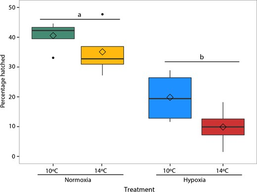

Figure 1:

Hatching success measured as percentage hatched in each treatment (10°C Normoxia [green], 10°C Hypoxia [blue], 14°C Normoxia [yellow], and 14°C Hypoxia [red]). The center line of the boxplots represents the median, the box represents the inter-quartile range (IQR), the whiskers extend 1.5 times IQR, black points represent values outside 1.5 the IQR, and diamonds represent the mean. Letters indicate a significant (*P* < 0.05) difference between dissolved oxygen treatments.

[Open in new tab](https://academic-oup-com.reed.idm.oclc.org/view-large/figure/132133556/coy078f01.tif)Download slide

### Upper thermal tolerance

#### Embryos

Upper thermal tolerance was highly variable across treatments and development (Fig. 2A). There was a significant two-way interaction between temperature and oxygen (*F*<sub>1, 120</sub> = 8.36, *P* = 0.005). In addition, a significant three-way interaction (*F*<sub>1,120</sub> = 36.30, *P* < 0.001) between the main effects of temperature (*F*<sub>1, 120</sub> = 12.05, *P* < 0.001), oxygen saturation (*F*<sub>1, 120</sub> = 145.44, *P* < 0.001) and developmental stage (*F*<sub>1, 120</sub> = 67.1, *P* < 0.001) indicated salmon CTMax was dependent on the life stage and stressors. For example, eyed stage embryos reared under hypoxia at both temperatures had the highest thermal tolerance with a CTMax of 30.6°C ± 0.6 at 10°C and 30.7°C ± 0.2 at 14°C. Eyed embryos reared at 14°C in normoxia had the lowest CTMax (27.9°C ± 0.2) and 10°C normoxia reared embryos had an intermediate thermal tolerance (28.9°C ± 0.2). Thermal tolerance significantly increased at the silver eyed stage for 10°C hypoxia and 14°C normoxia treatments. The 10°C hypoxia treatment had the highest CTMax (32.8°C ± 0.1) with both hypoxia treatments again being the most thermally tolerant. Silver eyed embryos in the 10°C normoxia treatment had the lowest CTMax (29.6°C ± 0.2) and 14°C normoxia was intermediate (30.4°C ± 0.3).

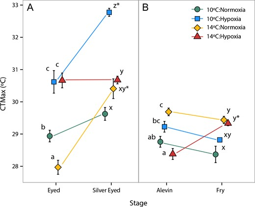

Figure 2:

[Open in new tab](https://academic-oup-com.reed.idm.oclc.org/view-large/figure/132133560/coy078f02.tif)Download slide

#### Alevins and fry

There were significant interactions between temperature, oxygen saturation, and developmental stage (*F*<sub>1,111</sub> = 7.68, *P* = 0.007) in the thermal tolerance of the post-hatch alevin and fry stages (Fig. 2B). There were significant two-way interactions between temperature and oxygen (*F*<sub>1,111</sub> = 35.03, *P* < 0.001) and temperature and stage (*F*<sub>1,111</sub> = 21.5, *P* < 0.001. There were also significant main effects of temperature (*F*<sub>1, 111</sub> = 16.9, *P* < 0.001), oxygen (*F*<sub>1, 111</sub> = 5.32, *P* = 0.02), and stage (*F*<sub>1, 111</sub> = 4.53, *P* = 0.04) on CTMax. At the alevin stage, the normoxia and hypoxia treatments at 14°C had the highest (29.7°C ± 0.1) and lowest CTMax (28.4°C ± 0.2), respectively, with the alevins reared at 10°C having intermediate CTMax (29.2°C ± 0.2 vs. 28.8°C ± 0.2 for hypoxia and normoxia treatments, respectively). Upon reaching the fry stage CTMax significantly increased in only the 14°C hypoxia treatment (increased to 29.3°C ± 0.1) such that it was no longer significantly different from the 14°C normoxia treatment. Both 14°C treatments had the highest CTMax, while the 10°C normoxia treatment had the lowest (28.4°C ± 0.3) CTMax.